# formatieve opdracht

Kjettil Evers

27-3-2023

Onderdeel 1a Schrijf een korte introductie voor de Rmarkdown met daarin in eigen woorden het doel van jouw onderzoek/analyses.

geïnduceerde pluripotente stamcellen (iPSC) zijn stamcellen die uit huidcellen (fibroblasten) worden gemaakt. De onderzoeksvraag van deze iPSC studie is: wat zijn de verschillen in genexpressie tussen iPSC en fibroblasten?

```r
library(tidyverse)
library(Rsubread)
```

Onderdeel 1b Stel dat de sample identifiers in een textfile staan. Schrijf een bash script voor het downloaden van de fastq files voor alle identifiers. Zorg ervoor dat dit script een for loop bevat, zodat je niet voor elke fastq file een aparte regel code hoeft te schrijven.

NB: voer dit script niet uit, want de fastq files zijn al voor jullie gedownload!

```bash
for id in $(cat fastq_id.txt)
do
fastq-dump --split-3 --outdir '/home/kjettil.evers/daur2/rnaseq_airway/fastq/' --gzip $id
done
```

Onderdeel 1c Bekijk de FastQC html rapporten voor de verschillende fastq files. Wat zijn je conclusies?

over het algemeen is de kwaliteit van de fastq files redelijk goed. wat opvalt is dat vooral aan het einde de per base sequence quality afneemt. maar deze ligt over het algemeen wel hoog genoeg om er mee te werken. de per sequence quality scores zien er ook goed uit dus de data is geschrikt om mee te werken SRR7866693_2.fastq lijkt geen goede data te hebben. bijna alles in oranje en rode gedeelte. (lage phred score)

Onderdeel 1d Schrijf code voor het uitvoeren van de alignment met de Rsubread package. Voor de alignment kun je gebruik maken van de hg38 genome index die is te vinden /home/daur2/rnaseq/hg38_index/

NB: voer dit script niet uit, want de alignment is al voor jullie uitgevoerd!

```r
library(tidyverse)
# Load the Rsubread package
library(Rsubread)

# Create object with location of fastq files
fastq_dir<- "/home/daur2/rnaseq/rnaseq_ipsc/fastq/."


# Create object with basename of index files
hg38_index<- "/home/daur2/rnaseq/hg38_index"

# Create object with output dir for bam files

bam_dir<- "~/daur2/formatieve_opdracht1/bamfiles"

# Create a vector with sample numbers
samples <- list.files(fastq_dir, pattern = "_[12].fastq.gz") %>%
  str_remove(pattern = "_[12].fastq.gz") %>%
  unique()

# Align the reads in the fastq files
alignment_statistics <- align(

  index = hg38_index,
  readfile1 = paste0(fastq_dir, samples, "_1.fastq.gz"),
  readfile2 = paste0(fastq_dir, samples, "_2.fastq.gz"),
  type = "rna", input_format = "gzFASTQ", output_format = "BAM",
  output_file = paste0(bam_dir, samples, ".bam"),

  # report only uniquely mapping reads
  unique = TRUE,

  # number of CPU threads
  nthreads = 10

)

# Store the alignment statistics as R object
saveRDS(alignment_statistics, file = paste0(bam_dir, "alignment_statistics.rds"))
```

Onderdeel 1e In de directory met de bam files kun je ook het bestand ‘alignment_statistics.rds’ vinden. Gebruik dit bestand om een grouped bar graph te maken met daarin voor elk sample zowel het percentage mapped fragments als het percentage unmapped fragments.

Wat is je conclusie op basis van deze grafiek?

```r
# Read the file into R
alignment_stats <- readRDS("/home/daur2/rnaseq/rnaseq_ipsc/bam/alignment_statistics.rds")

# Calculate the percentage of  (un)mapping fragments
alignment_stats_t <- alignment_stats %>%
  t %>%
  as_tibble() %>%
  mutate(bamfile=colnames(alignment_stats)) %>%
  mutate(perc_unique_mapped = Uniquely_mapped_fragments/Total_fragments*100, perc_mapped_fragments= Mapped_fragments/Total_fragments*100,
         perc_unmapped_fragments = 100-perc_mapped_fragments)
alignment_stats_t
```

```
## # A tibble: 8 × 16
##   Total_fragments Mapped_fragments Uniquely_mapped_fragments Multi_mapping_frag…
##             <int>            <int>                     <int>               <int>
## 1        36710982         25076902                  25076902                   0
## 2        31463551         27331319                  27331319                   0
## 3        19011731         16957862                  16957862                   0
## 4        27453732         24435961                  24435961                   0
## 5        28209568         21743585                  21743585                   0
## 6        29818588         24606955                  24606955                   0
## 7        17082047         14499377                  14499377                   0
## 8        12947645         10907317                  10907317                   0
## # … with 12 more variables: Unmapped_fragments <int>,
## #   Properly_paired_fragments <int>, Singleton_fragments <int>,
## #   More_than_one_chr_fragments <int>, Unexpected_strandness_fragments <int>,
## #   Unexpected_template_length <int>, Inversed_mapping <int>, Indels <int>,
## #   bamfile <chr>, perc_unique_mapped <dbl>, perc_mapped_fragments <dbl>,
## #   perc_unmapped_fragments <dbl>
```

```r
alignment_stats_t_tidy <- pivot_longer(data = alignment_stats_t, cols = c('perc_mapped_fragments', 'perc_unmapped_fragments'),
                             names_to = "fragments",  values_to = "percentage_mapped_unmapped")
alignment_stats_t_tidy
```

```
## # A tibble: 16 × 16
##    Total_fragments Mapped_fragments Uniquely_mapped_fragments Multi_mapping_fra…
##              <int>            <int>                     <int>              <int>
##  1        36710982         25076902                  25076902                  0
##  2        36710982         25076902                  25076902                  0
##  3        31463551         27331319                  27331319                  0
##  4        31463551         27331319                  27331319                  0
##  5        19011731         16957862                  16957862                  0
##  6        19011731         16957862                  16957862                  0
##  7        27453732         24435961                  24435961                  0
##  8        27453732         24435961                  24435961                  0
##  9        28209568         21743585                  21743585                  0
## 10        28209568         21743585                  21743585                  0
## 11        29818588         24606955                  24606955                  0
## 12        29818588         24606955                  24606955                  0
## 13        17082047         14499377                  14499377                  0
## 14        17082047         14499377                  14499377                  0
## 15        12947645         10907317                  10907317                  0
## 16        12947645         10907317                  10907317                  0
## # … with 12 more variables: Unmapped_fragments <int>,
## #   Properly_paired_fragments <int>, Singleton_fragments <int>,
## #   More_than_one_chr_fragments <int>, Unexpected_strandness_fragments <int>,
## #   Unexpected_template_length <int>, Inversed_mapping <int>, Indels <int>,
## #   bamfile <chr>, perc_unique_mapped <dbl>, fragments <chr>,
## #   percentage_mapped_unmapped <dbl>
```

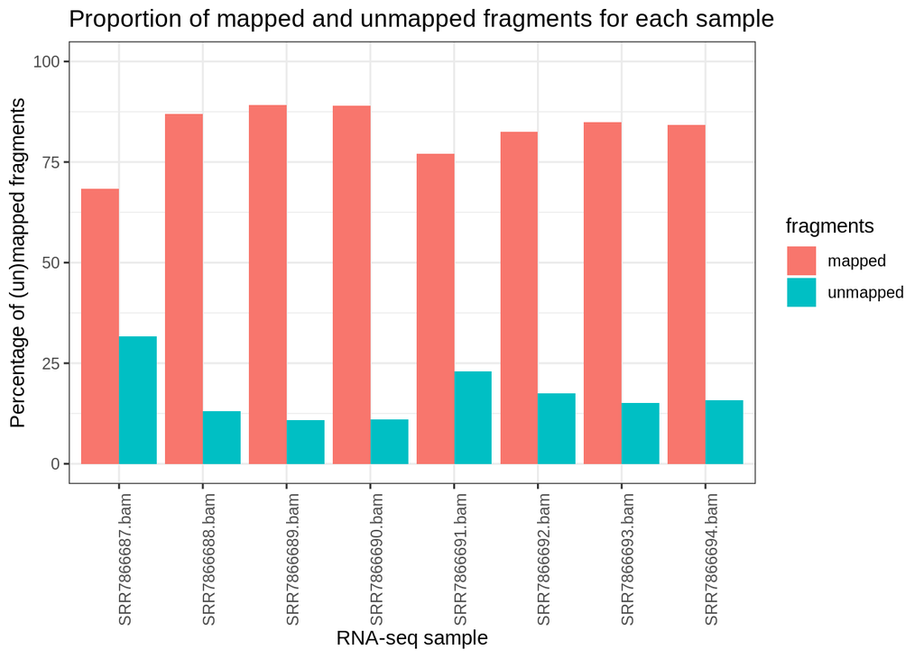

```r
# Plot the percentages in a bar graph
# Plot the percentages in a bar graph
alignment_stats_t_tidy %>% ggplot(aes(x = bamfile, y = percentage_mapped_unmapped, fill= fragments)) +
    geom_col(position = position_dodge()) +
  ggtitle("Proportion of mapped and unmapped fragments for each sample") +
  xlab("RNA-seq sample") +
  ylab("Percentage of (un)mapped fragments") +
  scale_fill_discrete(labels = c("mapped", "unmapped"))+
    theme_bw() +
  theme(axis.text.x = element_text(angle = 90)) +
  coord_cartesian (ylim =c(0,100))
```

vraag 2. Onderdeel 2a Schrijf code voor het genereren van de count table met de Rsubread package.

NB: voer dit script niet uit, want de count table is al voor jullie gegenereerd!

```r
# Load the required libraries
library(Rsubread)

# Create object with input dir for bam files
bam_dir <- "/home/daur2/rnaseq/rnaseq_ipsc/bam/."

# Create object with output dir for count tables
counts_dir <- "~/daur2/formatieve_opdracht1/counts/"
```

```r
# Create vector with names of bam files
bam_files <- list.files(bam_dir, pattern = ".*\\.bam$", full.names = TRUE)

# Count the reads per gene using the in-built NCBI RefSeq annotations
read_counts <- featureCounts(

  files = bam_files,
  annot.inbuilt = "hg38",
  useMetaFeatures = TRUE,
  strandSpecific = 0,
  isPairedEnd = TRUE,
  countReadPairs = TRUE,
  nthreads = 10
)
```

Onderdeel 2b Gebruik de ‘stat’ dataframe uit de count table om een staafdiagram te maken met daarin het percentage assigned reads voor elk sample.

Wat is je conclusie op basis van deze grafiek?

```r
# Load the count table into R
read_counts_ipsc <- readRDS("/home/daur2/rnaseq/rnaseq_ipsc/counts/./read_counts.rds")

# Inspect the count table object
str(read_counts_ipsc)
```

```
## List of 4
##  $ counts    : int [1:28395, 1:8] 1 13 1 0 0 0 4 3 44 0 ...
##   ..- attr(*, "dimnames")=List of 2
##   .. ..$ : chr [1:28395] "100287102" "653635" "102466751" "100302278" ...
##   .. ..$ : chr [1:8] "SRR7866687.bam" "SRR7866688.bam" "SRR7866689.bam" "SRR7866690.bam" ...
##  $ annotation:'data.frame':  28395 obs. of  6 variables:
##   ..$ GeneID: int [1:28395] 100287102 653635 102466751 100302278 645520 79501 729737 102725121 102723897 102465909 ...
##   ..$ Chr   : chr [1:28395] "chr1;chr1;chr1" "chr1;chr1;chr1;chr1;chr1;chr1;chr1;chr1;chr1;chr1;chr1" "chr1" "chr1" ...
##   ..$ Start : chr [1:28395] "11874;12613;13221" "14362;14970;15796;16607;16858;17233;17606;17915;18268;24738;29321" "17369" "30366" ...
##   ..$ End   : chr [1:28395] "12227;12721;14409" "14829;15038;15947;16765;17055;17368;17742;18061;18366;24891;29370" "17436" "30503" ...
##   ..$ Strand: chr [1:28395] "+;+;+" "-;-;-;-;-;-;-;-;-;-;-" "-" "+" ...
##   ..$ Length: int [1:28395] 1652 1769 68 138 1130 918 5474 1173 2120 68 ...
##  $ targets   : chr [1:8] "SRR7866687.bam" "SRR7866688.bam" "SRR7866689.bam" "SRR7866690.bam" ...
##  $ stat      :'data.frame':  14 obs. of  9 variables:
##   ..$ Status        : chr [1:14] "Assigned" "Unassigned_Unmapped" "Unassigned_Read_Type" "Unassigned_Singleton" ...
##   ..$ SRR7866687.bam: int [1:14] 16161707 11634080 0 0 0 0 0 0 0 0 ...
##   ..$ SRR7866688.bam: int [1:14] 19036043 4132232 0 0 0 0 0 0 0 0 ...
##   ..$ SRR7866689.bam: int [1:14] 12647535 2053869 0 0 0 0 0 0 0 0 ...
##   ..$ SRR7866690.bam: int [1:14] 17396979 3017771 0 0 0 0 0 0 0 0 ...
##   ..$ SRR7866691.bam: int [1:14] 10231920 6465983 0 0 0 0 0 0 0 0 ...
##   ..$ SRR7866692.bam: int [1:14] 12267837 5211633 0 0 0 0 0 0 0 0 ...
##   ..$ SRR7866693.bam: int [1:14] 7399996 2582670 0 0 0 0 0 0 0 0 ...
##   ..$ SRR7866694.bam: int [1:14] 6156291 2040328 0 0 0 0 0 0 0 0 ...
```

```r
# Obtain the dataframe with the statistics
count_stats <- read_counts_ipsc$stat
view(count_stats)

# Convert first column to rownames
rownames(count_stats) <- count_stats$Status
count_stats$Status <- NULL
view(count_stats)


# Calculate the percentage of uniquely counting fragments
count_stats_t <- count_stats %>%
  t %>%
  as_tibble() %>%
  mutate(bamfile=colnames(count_stats)) %>%
  mutate(Total=colSums(count_stats)) %>%
  mutate(perc_assigned = Assigned/Total*100)
count_stats_t
```

```
## # A tibble: 8 × 17
##   Assigned Unassigned_Unmapp… Unassigned_Read… Unassigned_Sing… Unassigned_Mapp…
##      <int>              <int>            <int>            <int>            <int>
## 1 16161707           11634080                0                0                0
## 2 19036043            4132232                0                0                0
## 3 12647535            2053869                0                0                0
## 4 17396979            3017771                0                0                0
## 5 10231920            6465983                0                0                0
## 6 12267837            5211633                0                0                0
## 7  7399996            2582670                0                0                0
## 8  6156291            2040328                0                0                0
## # … with 12 more variables: Unassigned_Chimera <int>,
## #   Unassigned_FragmentLength <int>, Unassigned_Duplicate <int>,
## #   Unassigned_MultiMapping <int>, Unassigned_Secondary <int>,
## #   Unassigned_NonSplit <int>, Unassigned_NoFeatures <int>,
## #   Unassigned_Overlapping_Length <int>, Unassigned_Ambiguity <int>,
## #   bamfile <chr>, Total <dbl>, perc_assigned <dbl>
```

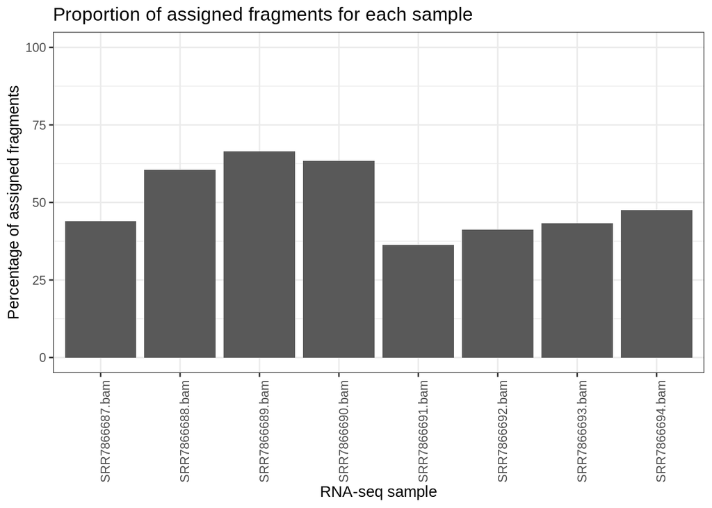

```r
# Plot the percentages in a bar graph
count_stats_t %>% ggplot(aes(x = bamfile, y = perc_assigned)) +
  geom_col() +
  ggtitle("Proportion of assigned fragments for each sample") +
  xlab("RNA-seq sample") +
  ylab("Percentage of assigned fragments") +
  theme_bw() +
  theme(axis.text.x = element_text(angle = 90)) +
  coord_cartesian (ylim =c(0,100))
```

Onderdeel 2c Gebruik de count table en het csv bestand met sample informatie om een DESeq2 object te maken.

```r
library(DESeq2)
# Obtain the count matrix
count_matrix <- read_counts_ipsc$counts

# Import the sample data
metadata <- read_csv("/home/daur2/rnaseq/rnaseq_ipsc/ipsc_sampledata.csv")
metadata
```

```
## # A tibble: 8 × 26
##   Run       `Assay Type` AvgSpotLen  Bases BioProject BioSample  Bytes Cell_line
##   <chr>     <chr>             <dbl>  <dbl> <chr>      <chr>      <dbl> <chr>
## 1 SRR78666… RNA-Seq              84 3.10e9 PRJNA4915… SAMN1007… 1.38e9 "Fibrobl…
## 2 SRR78666… RNA-Seq              85 2.68e9 PRJNA4915… SAMN1007… 1.01e9 "Fibrobl…
## 3 SRR78666… RNA-Seq              85 1.62e9 PRJNA4915… SAMN1007… 7.06e8 "Fibrobl…
## 4 SRR78666… RNA-Seq              85 2.34e9 PRJNA4915… SAMN1007… 8.77e8 "Fibrobl…
## 5 SRR78666… RNA-Seq              84 2.39e9 PRJNA4915… SAMN1007… 1.05e9 "iPSC li…
## 6 SRR78666… RNA-Seq              85 2.54e9 PRJNA4915… SAMN1007… 9.54e8 "iPSC li…
## 7 SRR78666… RNA-Seq              85 1.45e9 PRJNA4915… SAMN1007… 6.47e8 "iPSC li…
## 8 SRR78666… RNA-Seq              85 1.10e9 PRJNA4915… SAMN1007… 4.19e8 "iPSC li…
## # … with 18 more variables: Cell_type <chr>, `Center Name` <chr>,
## #   Consent <chr>, `DATASTORE filetype` <chr>, `DATASTORE provider` <chr>,
## #   `DATASTORE region` <chr>, Experiment <chr>, `GEO_Accession (exp)` <chr>,
## #   Instrument <chr>, LibraryLayout <chr>, LibrarySelection <chr>,
## #   LibrarySource <chr>, Organism <chr>, Platform <chr>, ReleaseDate <dttm>,
## #   `Sample Name` <chr>, source_name <chr>, `SRA Study` <chr>
```

```r
# Convert the metadata to dataframe object
metadata <- as.data.frame(metadata)

# Add rownames to the metadata dataframe
rownames(metadata) <- paste0(metadata$Run, ".bam")

# Show first lines of metadata object
head(metadata)
```

```
##                       Run Assay Type AvgSpotLen      Bases  BioProject
## SRR7866687.bam SRR7866687    RNA-Seq         84 3100625705 PRJNA491516
## SRR7866688.bam SRR7866688    RNA-Seq         85 2678322059 PRJNA491516
## SRR7866689.bam SRR7866689    RNA-Seq         85 1617791810 PRJNA491516
## SRR7866690.bam SRR7866690    RNA-Seq         85 2335911220 PRJNA491516
## SRR7866691.bam SRR7866691    RNA-Seq         84 2388288424 PRJNA491516
## SRR7866692.bam SRR7866692    RNA-Seq         85 2538209760 PRJNA491516
##                   BioSample      Bytes
## SRR7866687.bam SAMN10079885 1380751688
## SRR7866688.bam SAMN10079883 1005565315
## SRR7866689.bam SAMN10079882  705929729
## SRR7866690.bam SAMN10079881  876704451
## SRR7866691.bam SAMN10079879 1052227406
## SRR7866692.bam SAMN10079878  954131990
##                                                            Cell_line
## SRR7866687.bam                         Fibroblast line 1 (CL1500023)
## SRR7866688.bam                         Fibroblast line 1 (CL1500023)
## SRR7866689.bam                         Fibroblast line 2 (CL1500024)
## SRR7866690.bam                         Fibroblast line 2 (CL1500024)
## SRR7866691.bam iPSC line 1 (IPS1500030/C2\\, derived from CL1500023)
## SRR7866692.bam iPSC line 1 (IPS1500030/C2\\, derived from CL1500023)
##                              Cell_type Center Name Consent DATASTORE filetype
## SRR7866687.bam Skin derived fibroblast         GEO  public          fastq,sra
## SRR7866688.bam Skin derived fibroblast         GEO  public          fastq,sra
## SRR7866689.bam Skin derived fibroblast         GEO  public          fastq,sra
## SRR7866690.bam Skin derived fibroblast         GEO  public          fastq,sra
## SRR7866691.bam                    iPSC         GEO  public          fastq,sra
## SRR7866692.bam                    iPSC         GEO  public          fastq,sra
##                DATASTORE provider               DATASTORE region Experiment
## SRR7866687.bam         gs,ncbi,s3 gs.US,ncbi.public,s3.us-east-1 SRX4705867
## SRR7866688.bam         gs,ncbi,s3 gs.US,ncbi.public,s3.us-east-1 SRX4705868
## SRR7866689.bam         gs,ncbi,s3 gs.US,ncbi.public,s3.us-east-1 SRX4705869
## SRR7866690.bam         gs,ncbi,s3 gs.US,ncbi.public,s3.us-east-1 SRX4705870
## SRR7866691.bam         gs,ncbi,s3 gs.US,ncbi.public,s3.us-east-1 SRX4705871
## SRR7866692.bam         gs,ncbi,s3 gs.US,ncbi.public,s3.us-east-1 SRX4705872
##                GEO_Accession (exp)  Instrument LibraryLayout LibrarySelection
## SRR7866687.bam          GSM3393001 NextSeq 500        PAIRED             cDNA
## SRR7866688.bam          GSM3393002 NextSeq 500        PAIRED             cDNA
## SRR7866689.bam          GSM3393003 NextSeq 500        PAIRED             cDNA
## SRR7866690.bam          GSM3393004 NextSeq 500        PAIRED             cDNA
## SRR7866691.bam          GSM3393005 NextSeq 500        PAIRED             cDNA
## SRR7866692.bam          GSM3393006 NextSeq 500        PAIRED             cDNA
##                 LibrarySource     Organism Platform ReleaseDate Sample Name
## SRR7866687.bam TRANSCRIPTOMIC Homo sapiens ILLUMINA  2019-04-05  GSM3393001
## SRR7866688.bam TRANSCRIPTOMIC Homo sapiens ILLUMINA  2019-04-05  GSM3393002
## SRR7866689.bam TRANSCRIPTOMIC Homo sapiens ILLUMINA  2019-04-05  GSM3393003
## SRR7866690.bam TRANSCRIPTOMIC Homo sapiens ILLUMINA  2019-04-05  GSM3393004
## SRR7866691.bam TRANSCRIPTOMIC Homo sapiens ILLUMINA  2019-04-05  GSM3393005
## SRR7866692.bam TRANSCRIPTOMIC Homo sapiens ILLUMINA  2019-04-05  GSM3393006
##                      source_name SRA Study
## SRR7866687.bam Fibroblast line 1 SRP161949
## SRR7866688.bam Fibroblast line 1 SRP161949
## SRR7866689.bam Fibroblast line 2 SRP161949
## SRR7866690.bam Fibroblast line 2 SRP161949
## SRR7866691.bam       iPSC line 1 SRP161949
## SRR7866692.bam       iPSC line 1 SRP161949
```

```r
# Check if column names of count table are the same as row names of metadata object
colnames(count_matrix) == rownames(metadata)
```

```
## [1] TRUE TRUE TRUE TRUE TRUE TRUE TRUE TRUE
```

```r
# Create a column specifying the test condition
metadata <- metadata %>% mutate(celtype = c("Fibroblast", "Fibroblast", "Fibroblast", "Fibroblast", "iPSC", "iPSC", "iPSC", "iPSC"))
metadata
```

```
##                       Run Assay Type AvgSpotLen      Bases  BioProject
## SRR7866687.bam SRR7866687    RNA-Seq         84 3100625705 PRJNA491516
## SRR7866688.bam SRR7866688    RNA-Seq         85 2678322059 PRJNA491516
## SRR7866689.bam SRR7866689    RNA-Seq         85 1617791810 PRJNA491516
## SRR7866690.bam SRR7866690    RNA-Seq         85 2335911220 PRJNA491516
## SRR7866691.bam SRR7866691    RNA-Seq         84 2388288424 PRJNA491516
## SRR7866692.bam SRR7866692    RNA-Seq         85 2538209760 PRJNA491516
## SRR7866693.bam SRR7866693    RNA-Seq         85 1452793492 PRJNA491516
## SRR7866694.bam SRR7866694    RNA-Seq         85 1102004504 PRJNA491516
##                   BioSample      Bytes
## SRR7866687.bam SAMN10079885 1380751688
## SRR7866688.bam SAMN10079883 1005565315
## SRR7866689.bam SAMN10079882  705929729
## SRR7866690.bam SAMN10079881  876704451
## SRR7866691.bam SAMN10079879 1052227406
## SRR7866692.bam SAMN10079878  954131990
## SRR7866693.bam SAMN10079876  647030445
## SRR7866694.bam SAMN10079875  419226920
##                                                             Cell_line
## SRR7866687.bam                          Fibroblast line 1 (CL1500023)
## SRR7866688.bam                          Fibroblast line 1 (CL1500023)
## SRR7866689.bam                          Fibroblast line 2 (CL1500024)
## SRR7866690.bam                          Fibroblast line 2 (CL1500024)
## SRR7866691.bam  iPSC line 1 (IPS1500030/C2\\, derived from CL1500023)
## SRR7866692.bam  iPSC line 1 (IPS1500030/C2\\, derived from CL1500023)
## SRR7866693.bam iPSC line 2 (IPS1500024/293\\, derived from CL1500024)
## SRR7866694.bam iPSC line 2 (IPS1500024/293\\, derived from CL1500024)
##                              Cell_type Center Name Consent DATASTORE filetype
## SRR7866687.bam Skin derived fibroblast         GEO  public          fastq,sra
## SRR7866688.bam Skin derived fibroblast         GEO  public          fastq,sra
## SRR7866689.bam Skin derived fibroblast         GEO  public          fastq,sra
## SRR7866690.bam Skin derived fibroblast         GEO  public          fastq,sra
## SRR7866691.bam                    iPSC         GEO  public          fastq,sra
## SRR7866692.bam                    iPSC         GEO  public          fastq,sra
## SRR7866693.bam                    iPSC         GEO  public          fastq,sra
## SRR7866694.bam                    iPSC         GEO  public          fastq,sra
##                DATASTORE provider               DATASTORE region Experiment
## SRR7866687.bam         gs,ncbi,s3 gs.US,ncbi.public,s3.us-east-1 SRX4705867
## SRR7866688.bam         gs,ncbi,s3 gs.US,ncbi.public,s3.us-east-1 SRX4705868
## SRR7866689.bam         gs,ncbi,s3 gs.US,ncbi.public,s3.us-east-1 SRX4705869
```

[output cut: 17 more lines]

```
## SRR7866689.bam TRANSCRIPTOMIC Homo sapiens ILLUMINA  2019-04-05  GSM3393003
## SRR7866690.bam TRANSCRIPTOMIC Homo sapiens ILLUMINA  2019-04-05  GSM3393004
## SRR7866691.bam TRANSCRIPTOMIC Homo sapiens ILLUMINA  2019-04-05  GSM3393005
## SRR7866692.bam TRANSCRIPTOMIC Homo sapiens ILLUMINA  2019-04-05  GSM3393006
## SRR7866693.bam TRANSCRIPTOMIC Homo sapiens ILLUMINA  2019-04-05  GSM3393007
## SRR7866694.bam TRANSCRIPTOMIC Homo sapiens ILLUMINA  2019-04-05  GSM3393008
##                      source_name SRA Study    celtype
## SRR7866687.bam Fibroblast line 1 SRP161949 Fibroblast
## SRR7866688.bam Fibroblast line 1 SRP161949 Fibroblast
## SRR7866689.bam Fibroblast line 2 SRP161949 Fibroblast
## SRR7866690.bam Fibroblast line 2 SRP161949 Fibroblast
## SRR7866691.bam       iPSC line 1 SRP161949       iPSC
## SRR7866692.bam       iPSC line 1 SRP161949       iPSC
## SRR7866693.bam       iPSC line 2 SRP161949       iPSC
## SRR7866694.bam       iPSC line 2 SRP161949       iPSC
```

```r
metadata$celtype <- metadata$celtype %>% factor(levels = c("Fibroblast", "iPSC"))


levels(metadata$celtype)
```

```
## [1] "Fibroblast" "iPSC"
```

```r
# Create the DESeqDataSet object
dds_ipsc <- DESeqDataSetFromMatrix(
  countData = count_matrix,
  colData = metadata,
  design = ~ celtype
)

dds_ipsc
```

```
## class: DESeqDataSet
## dim: 28395 8
## metadata(1): version
## assays(1): counts
## rownames(28395): 100287102 653635 ... 102723822 102723891
## rowData names(0):
## colnames(8): SRR7866687.bam SRR7866688.bam ... SRR7866693.bam
##   SRR7866694.bam
## colData names(27): Run Assay Type ... SRA Study celtype
```

```r
dds_ipsc_normalized <- rlog(dds_ipsc)
```

vraag 2d Voer een PCA analyse uit en maak een plot van PC1 versus PC2.

Wat is je conclusie op basis van deze plot?

```r
# Perform PCA on the iPSC study dataset
pca <- dds_ipsc_normalized %>% assay() %>% t() %>% prcomp()


# Find the proportion of variance explained by each PC
pca_summary <- summary(pca)$importance
pca_summary
```

```
##                             PC1      PC2      PC3      PC4      PC5      PC6
## Standard deviation     142.2719 40.35777 32.49051 23.05517 20.72753 20.56573
## Proportion of Variance   0.8221  0.06615  0.04287  0.02159  0.01745  0.01718
## Cumulative Proportion    0.8221  0.88826  0.93113  0.95272  0.97017  0.98735
##                             PC7          PC8
## Standard deviation     17.65039 2.954666e-13
## Proportion of Variance  0.01265 0.000000e+00
## Cumulative Proportion   1.00000 1.000000e+00
```

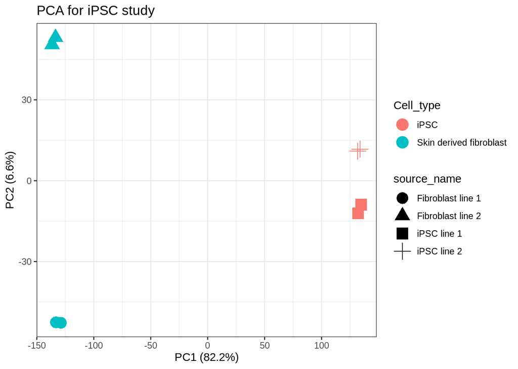

```r
# Create data frame with metadata and the PCA values for plotting
pca_plotting <- cbind(metadata, pca$x)

# Obtain the percentages of variation covered by PC1 and PC2
PC1_var <- round(pca_summary["Proportion of Variance", "PC1"]*100, digits = 1)
PC2_var <- round(pca_summary["Proportion of Variance", "PC2"]*100, digits = 1)

# Plot PC1 vs PC2
ggplot(pca_plotting) +
  geom_point(aes(x=PC1, y=PC2, color = Cell_type, shape = source_name), size = 5) +
  ggtitle("PCA for iPSC study") +
  xlab(paste0("PC1 (", PC1_var, "%)")) +
  ylab(paste0("PC2 (", PC2_var, "%)")) +
  theme_bw()
```

conclusie: The first PC, PC1, captures about 80% of the variation in the data. Based on PC1, the samples are separated in two groups, which correspond to the different celtypes. This is something we want to see, because we expect that the different celtypes have different gene expression and that these changes are the biggest signal in the data.

PC2 captures about 6% of the variation. we can see that all cell lines differ from each other. However, it is expected that any remaining variation in gene expression (besides the variation explained by celltype) is due to differences between the cell lines

Onderdeel 2e Maak een heatmap waarin de correlatiecoëfficiënten voor de verschillende samples zijn weergegeven.

Wat is je conclusie op basis van deze heatmap?

```r
# Extract the matrix from the normalized DESeq object
dds_ipsc_normalized_matrix <- assay(dds_ipsc_normalized)

# Compute pairwise correlation values
ipsc_cor <- cor(dds_ipsc_normalized_matrix)
ipsc_cor
```

```
##                SRR7866687.bam SRR7866688.bam SRR7866689.bam SRR7866690.bam
## SRR7866687.bam      1.0000000      0.9950931      0.9870801      0.9874808
## SRR7866688.bam      0.9950931      1.0000000      0.9870472      0.9874331
## SRR7866689.bam      0.9870801      0.9870472      1.0000000      0.9945846
## SRR7866690.bam      0.9874808      0.9874331      0.9945846      1.0000000
## SRR7866691.bam      0.9312079      0.9284086      0.9282231      0.9272648
## SRR7866692.bam      0.9287741      0.9279841      0.9272618      0.9262506
## SRR7866693.bam      0.9285853      0.9266970      0.9277809      0.9267929
## SRR7866694.bam      0.9293349      0.9283976      0.9290495      0.9279319
##                SRR7866691.bam SRR7866692.bam SRR7866693.bam SRR7866694.bam
## SRR7866687.bam      0.9312079      0.9287741      0.9285853      0.9293349
## SRR7866688.bam      0.9284086      0.9279841      0.9266970      0.9283976
## SRR7866689.bam      0.9282231      0.9272618      0.9277809      0.9290495
## SRR7866690.bam      0.9272648      0.9262506      0.9267929      0.9279319
## SRR7866691.bam      1.0000000      0.9946553      0.9896967      0.9895379
## SRR7866692.bam      0.9946553      1.0000000      0.9894378      0.9902803
## SRR7866693.bam      0.9896967      0.9894378      1.0000000      0.9933892
## SRR7866694.bam      0.9895379      0.9902803      0.9933892      1.0000000
```

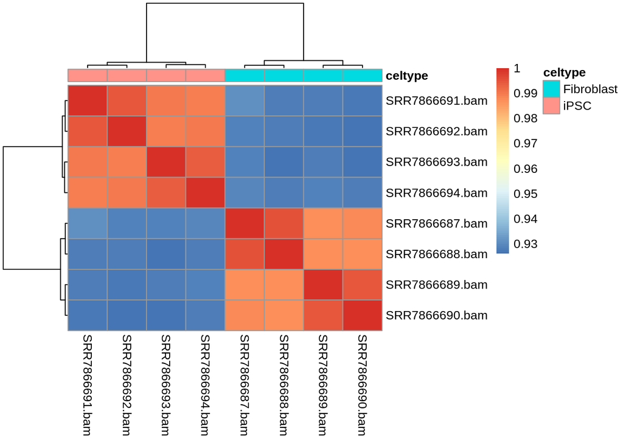

```r
# Load pheatmap package
library(pheatmap)

# Plot heatmap using the correlation; annotate the heatmap based on the treatment
pheatmap(ipsc_cor, annotation = metadata["celtype"])
```

Onderdeel 3a Voer de DGE analyse uit met behulp van DESeq2. Hoeveel genen zijn er upgereguleerd (adjusted p-value < 0.05 en LFC > 1)? En hoeveel genen zijn er downgereguleerd (adjusted p-value < 0.05 en LFC < -1)?

Vergelijk de aantallen met de aantallen voor de airway studie. Wat is je conclusie?

```r
ipsc_dge <- DESeq(dds_ipsc)
ipsc_dge
```

```
## class: DESeqDataSet
## dim: 28395 8
## metadata(1): version
## assays(4): counts mu H cooks
## rownames(28395): 100287102 653635 ... 102723822 102723891
## rowData names(22): baseMean baseVar ... deviance maxCooks
## colnames(8): SRR7866687.bam SRR7866688.bam ... SRR7866693.bam
##   SRR7866694.bam
## colData names(28): Run Assay Type ... celtype sizeFactor
```

```r
# Obtain the results for the DGE analysis
ipsc_dge_results <- results(ipsc_dge, alpha = 0.05, lfcThreshold = 1)
view(ipsc_dge_results)

# Obtain the summary of the results
summary(ipsc_dge_results)
```

```
##
## out of 23095 with nonzero total read count
## adjusted p-value < 0.05
## LFC > 1.00 (up)    : 3222, 14%
## LFC < -1.00 (down) : 2510, 11%
## outliers [1]       : 3, 0.013%
## low counts [2]     : 4424, 19%
## (mean count < 1)
## [1] see 'cooksCutoff' argument of ?results
## [2] see 'independentFiltering' argument of ?results
```

Onderdeel 3b Create a Volcano plot in which you colour all genes with an adjusted p-value < 0.05 and |LFC|>1 darkblue. Also indicate the LFC and p-value thresholds as dashed lines in the plot.

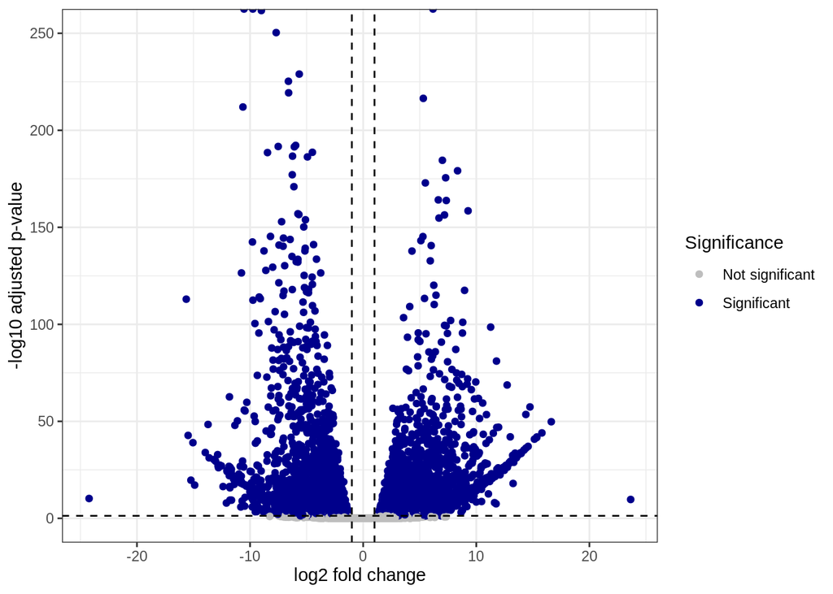

```r
################################################################# voor de lol
# Obtain the genes with a significant p-value
## sign_genes_ipsc <- ipsc_dge_results[which(ipsc_dge_results$padj < 0.05),]

# Obtain the id of the most significantly upregulated gene
## topGene_ipsc <- sign_genes_ipsc[which.max(sign_genes$log2FoldChange),]
## topGene_name_ipsc <- rownames(topGene)
## topGene_name_ipsc
###############################################################

# Create a dataframe for plotting without genes with padj = NA
ipsc_dge_plotting <- data.frame(ipsc_dge_results) %>% filter(!is.na(padj))

# Create column specifying if gene is significantly differentially expressed
ipsc_dge_plotting <- ipsc_dge_plotting %>%
  mutate(signif = if_else(padj < 0.05 & abs(log2FoldChange) > 1,
                          "Significant", "Not significant"))



# Create a volcano plot
ipsc_dge_plotting %>%
  ggplot(aes(x = log2FoldChange, y = -log10(padj), color = signif)) +
  geom_point() +
  xlab("log2 fold change") +
  ylab("-log10 adjusted p-value") +
  theme_bw() +

  # Change the legend text and the colours
  scale_colour_manual(values = c("grey", "darkblue"), name = "Significance")+

####################################################################################  voor de lol
  # Annotate the most significantly upregulated gene
 ## annotate("text", x = topGene_ipsc$log2FoldChange, y = -log10(topGene_ipsc$padj)*0.8,
   ##        label = topGene_name_ipsc, colour = "blue") +
########################################################################################

  #threshold LFC en p.value
   geom_hline(yintercept = -log10(0.05), linetype = "dashed") +
  geom_vline(xintercept = 1, linetype = "dashed") +
  geom_vline(xintercept = -1, linetype = "dashed") +
    coord_cartesian (ylim =c(0,250))
```

```r
# Obtain the gene identifiers of the 15 most significant genes
ipsc_dge_results_padj<- ipsc_dge_results %>% as.data.frame() %>% filter(padj < 0.05)

top15_genes_ipsc <- rownames(ipsc_dge_results_padj[order(abs(ipsc_dge_results_padj$log2FoldChange))[1:15],])

# Obtain the count values for these genes
count_values_ipsc <- assay(dds_ipsc)[top15_genes_ipsc,]
count_values_ipsc
```

```
##        SRR7866687.bam SRR7866688.bam SRR7866689.bam SRR7866690.bam
## 8467             3827           4626           2521           3428
## 9889              646            765            430            625
## 200081           4041           4460           2862           3820
## 50809            4300           4901           2710           4120
## 4771             3828           4315           2540           3535
## 23365            8467          10365           6145           9004
## 23243            4020           4623           2548           3796
## 85440            3714           4746           2867           3848
## 811             35007          40093          19806          28442
## 166647            579            673            323            512
## 3615             2109           2509           1430           1805
## 103910           6961           8017           5578           8244
## 23019            4565           5906           2983           4428
## 2186             4703           5097           3435           4731
```

[output cut: 17 more lines]

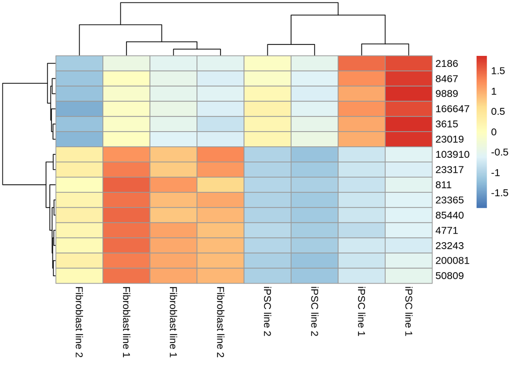

```r
# Replace the column names with conditions
colnames(count_values_ipsc) <- colData(dds_ipsc)$source_name

# Visualize the results in a heatmap
pheatmap(count_values_ipsc,  scale = "row", show_rownames = TRUE)
```

les 4

Onderdeel 4a Maak een heatmap zoals bij onderdeel 3c. Echter, zorg ervoor dat de rijen nu gelabeld worden met het gensymbool i.p.v. de Entrez identifier.

```r
library("org.Hs.eg.db")
library(GOstats)
```

```r
# Create an extra column with the Entrez id (based on rownames)
count_values_ipsc_gen <- data.frame(count_values_ipsc) %>% mutate(entrezid = rownames(count_values_ipsc))



# Obtain the gene symbols based on the Entrez identifiers
count_values_ipsc_gen$symbol <- mapIds(org.Hs.eg.db,
                             keys = count_values_ipsc_gen$entrezid,
                             column = "SYMBOL",
                             keytype = "ENTREZID",
                             multiVals = "first")
rownames(count_values_ipsc)<- count_values_ipsc_gen$symbol

count_values_ipsc
```

```
##          Fibroblast line 1 Fibroblast line 1 Fibroblast line 2
## SMARCA5               3827              4626              2521
## ZBED4                  646               765               430
## TXLNA                 4041              4460              2862
## HP1BP3                4300              4901              2710
## NF2                   3828              4315              2540
## ARHGEF12              8467             10365              6145
## ANKRD28               4020              4623              2548
## DOCK7                 3714              4746              2867
## CALR                 35007             40093             19806
## ADGRA3                 579               673               323
## IMPDH2                2109              2509              1430
## MYL12B                6961              8017              5578
## CNOT1                 4565              5906              2983
## BPTF                  4703              5097              3435
## DNAJC13               4761              5943              3870
##          Fibroblast line 2 iPSC line 1 iPSC line 1 iPSC line 2 iPSC line 2
## SMARCA5               3428        6961        8077        4520        3538
## ZBED4                  625        1156        1427         853         596
## TXLNA                 3820        1307        1601         896         639
## HP1BP3                4120        1351        1724         864         675
## NF2                   3535        1007        1365         914         685
## ARHGEF12              9004        2800        3339        1971        1540
## ANKRD28               3796        1244        1313         907         706
## DOCK7                 3848        1257        1470         880         691
## CALR                 28442        9105       12444        6674        5895
## ADGRA3                 512        1016        1144         758         537
## IMPDH2                1805        3677        4492        2795        2144
## MYL12B                8244        2430        2893        1692        1190
## CNOT1                 4428        8183       10103        6314        5012
## BPTF                  4731        9725       10216        5991        4784
## DNAJC13               5558        1603        1831        1192         948
```

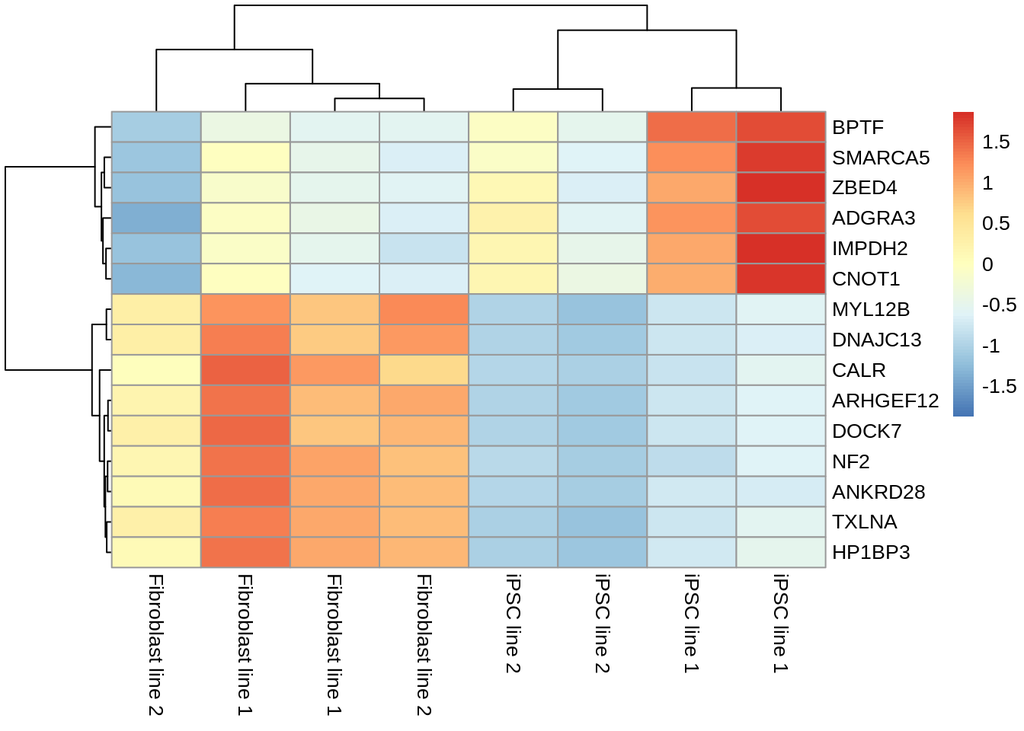

```r
# Replace the column names with conditions
colnames(count_values_ipsc) <- colData(dds_ipsc)$source_name

pheatmap(count_values_ipsc,  scale = "row", show_rownames = TRUE)
```

Onderdeel 4b Schrijf een functie voor het uitvoeren van de GO term enrichment analyse. Deze functie heeft 4 input argumenten:

DESeq2 results object (results(DESeq(dds)))

Logische waarde (TRUE of FALSE) die aangeeft of de enrichment analyse gedaan moet worden voor de upgereguleerde genen of voor de downgereguleerde genen.

Drempelwaarde voor |LFC|.

Drempelwaarde voor adjusted p-waarde.

De output van de functie is de summary van de GO term analyse (summary(hyperGTest(test_object)))

Bijvoorbeeld: gotermAnalysis(ipsc_dge_results, upregulated = FALSE, 1, 0.01) geeft de summary van de enrichment analyse voor de downgereguleerde genen met een LFC < -1 en een adjusted p-waarde < 0.01 voor de genen in het DESeq2 results object ipsc_dge_results.

```r
gotermAnalysis<- function(dge_results, upregulated, lfcthreshold, padjthershold) {

  # Load the GOstats library
library(GOstats)

if(upregulated == TRUE){

regulated<- "upregulated"

# Create a list of upregulated genes
regulated_genes <- dge_results %>% data.frame() %>%
  filter(log2FoldChange > lfcthreshold, padj < padjthershold) %>% rownames()

}else if (upregulated == FALSE)  {

  regulated<- "downregulated"

# Create a list of upregulated genes
regulated_genes <- dge_results %>% data.frame() %>%

    filter(log2FoldChange < -lfcthreshold, padj < padjthershold) %>% rownames()
}


# Create a list of all genes in the dataset
all_genes <- dge_results %>% data.frame() %>% rownames()

# Perform GO term enrichment analysis
GO_term <- new("GOHyperGParams",
                   geneIds = regulated_genes,
                   universeGeneIds = all_genes,
                   annotation = "org.Hs.eg.db",
                   ontology = "BP",
                   pvalueCutoff = 1,
                   testDirection = "over")
goterm_analysis <- hyperGTest(GO_term)


# Obtains dataframe with results of GO term analysis
goterm_analysis_results <- summary(goterm_analysis)

goterm_analysis_results

# Adjust the p values for multiple testing
goterm_analysis_results$padj <- p.adjust(goterm_analysis_results$Pvalue, method = "BH")

# Select only gene sets that are larger than 5 but smaller
# than 500 (to prevent taking along very small and very large
# gene sets).
goterm_analysis_results <- goterm_analysis_results %>% filter(Count > 5) %>% filter(Count < 500)

# Select the top 20 GO terms
goterm_analysis_top20 <- goterm_analysis_results[order(goterm_analysis_results$padj)[1:20],]

# Plot the p-values of the top 20 GO terms
goterm_analysis_top20$Term <- factor(goterm_analysis_top20$Term,
                                     levels = goterm_analysis_top20$Term[
                                       order(goterm_analysis_top20$padj, decreasing = TRUE)])
goterm_analysis_top20 %>% ggplot(aes(x = Term, y = -log10(padj))) +
  geom_point() +
  coord_flip() +
  ylab(expression(-log[10](adjusted~italic(P)~value))) +
  xlab("GO terms") +
  ggtitle(paste("Top 20 enriched GO terms\n for", regulated, "genes")) +
  theme_bw()

}
```

vraag 4 c

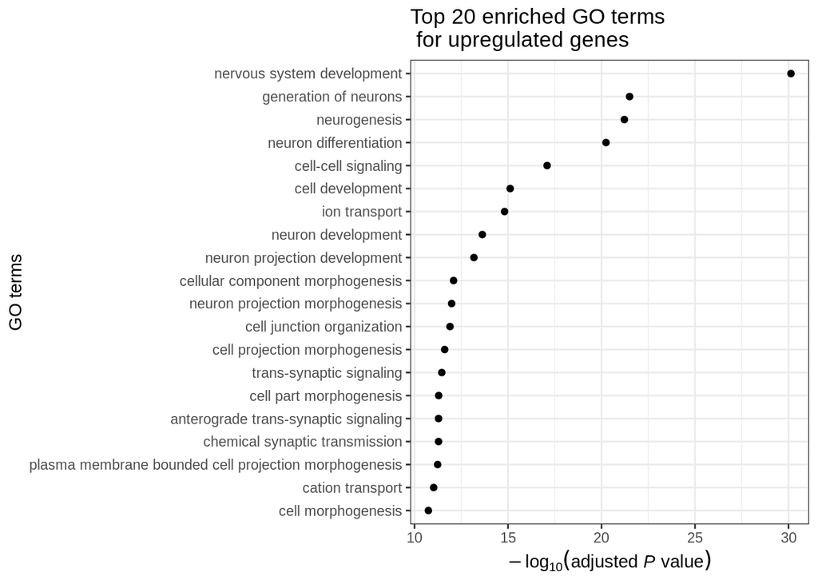

```r
gotermAnalysis(ipsc_dge_results, upregulated = TRUE, 1, 0.01)
```

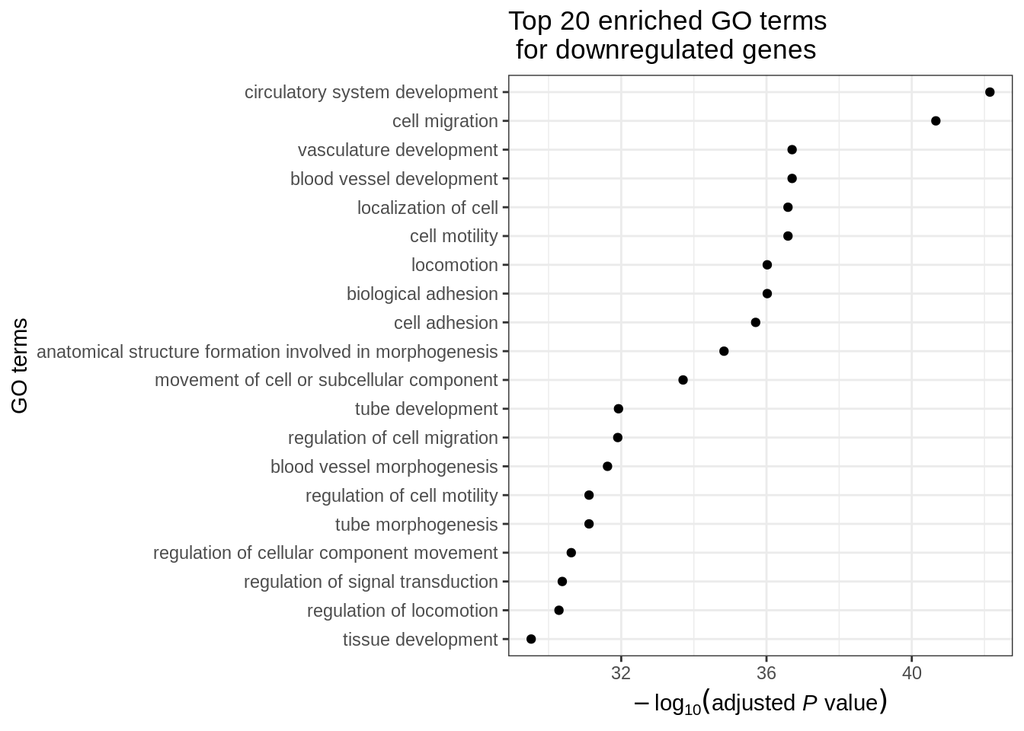

```r
gotermAnalysis(ipsc_dge_results, upregulated = FALSE, 1, 0.01)
```